# Peace Corps Data Analysis

Tivas Gupta

4/25/2020

## Overview

This data is difficult to perform regressions or more predictive analysis on because we have nothing to compare the Peace Corp effect to. We could do regressions or determine causal effects if we had the data of similar people not in the Peace Corps. Even if we had the length of time one spent in the Peace Corp program, we could see if there are marginal effects between volunteers.

## Visual Analysis

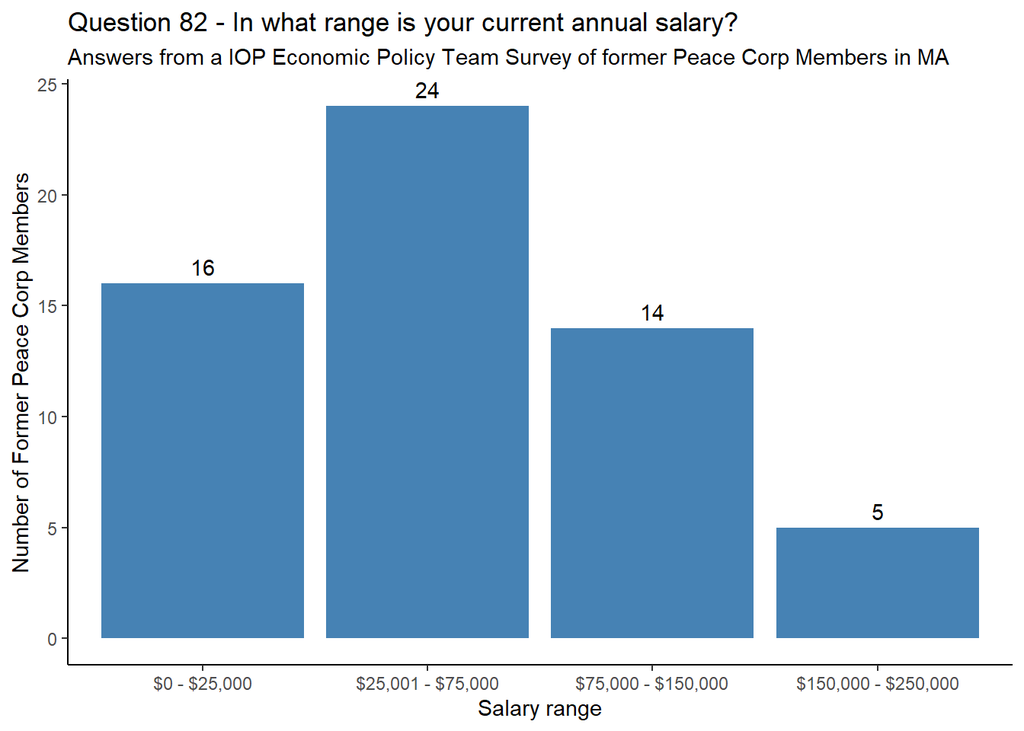

The above barplot shows the frequency of each salary range. We see that the $25,000 to $75,000 range is the most frequent, folowed by the $0-$25,000, $75,000 - $150,000, and finally the $150,000 - $250,000 range. 49 people who filled out this survey chose not to answer this question.

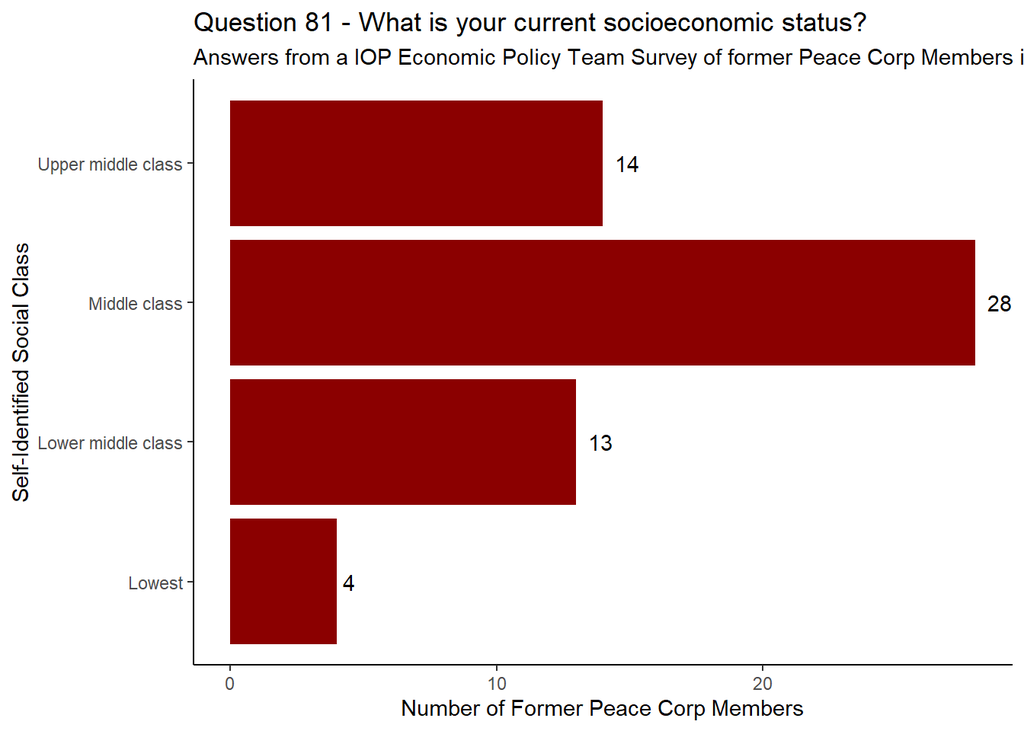

The barplot shows the number of Peace Corp volunteers that identified in each social class. The most common self-identification was “Middle Class”, followed by “Upper middle class”, “Lower middle class”, and finally “Lowest”. 45 people chose not to answer this question.

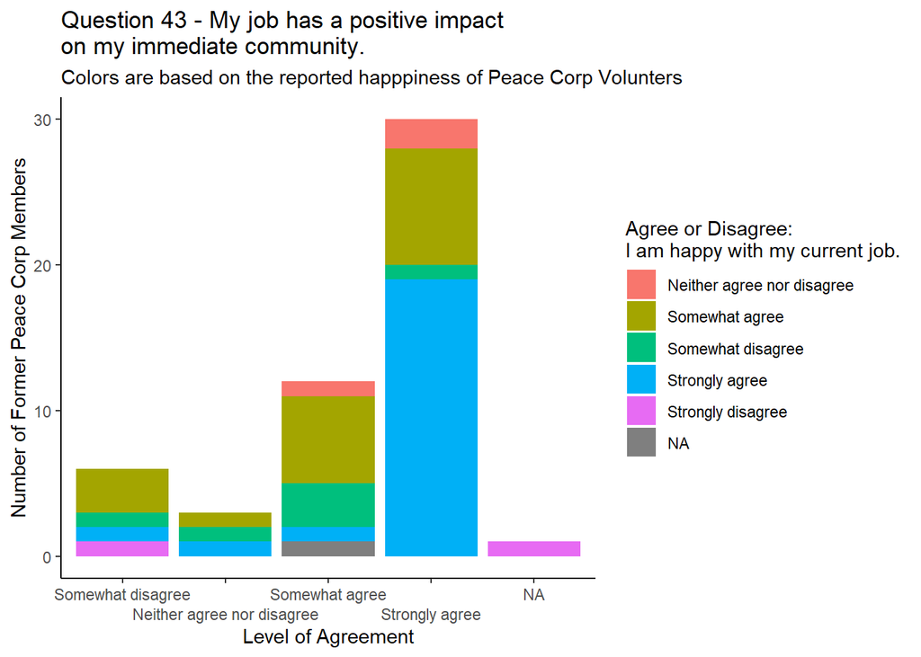

On this graph we see how Peace Corp Volunteers thought their current jobs had a positive impact on their immediate community. The graphs show that most fomer volunteers thought their current job had a positive impact on their immediate community. Visually, it would also appear that those who were happiest in their jobs believed their work was impacting their immediate community.